# California Jailing Population between Asian American / Pacific Islander and White

Xiyah Chang

2022/2/23

## Introduction

This is a report related to jailing of two selected race, *Asian American/Pacific Islander(AAPI)*, and *White* in *California, U.S*. As an international student who is an Asian, I am interested to explore this data set to understand whether the report will show an obvious racism through *comparing the white race jailing to AAPI race jailing*.

Looking at the data for California only, there are **48** years records.

The prison population is the total number of population in the prison on Dec. 31 of the current recorded year. By looking through the data set, in California, **2006** has the highest total prison population rate **685.2744828**, which is calculated by “total prison population of the year/total population”.

If we look closer into the year of 2006, we can notice that the average white prison population rate is **553.5114545**, whereas the average AAPI prison population rate is **70.264**, with differences **483.2474545**.

## Charts Over Time

Below is a chart of the white prison population rate, throughout the given 48 years.

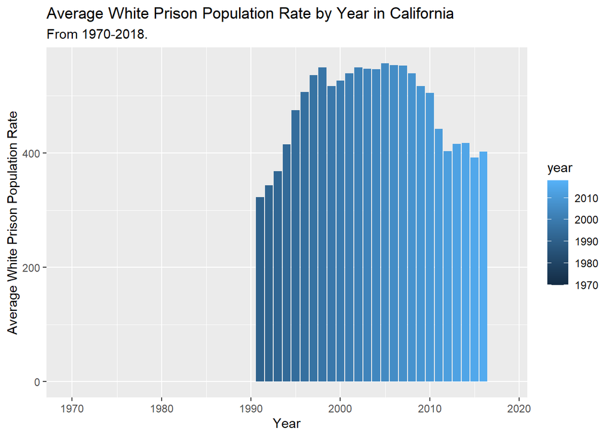

[output not shown]

Below is a chart of the aapi prison population rate, throughout the given 48 years.

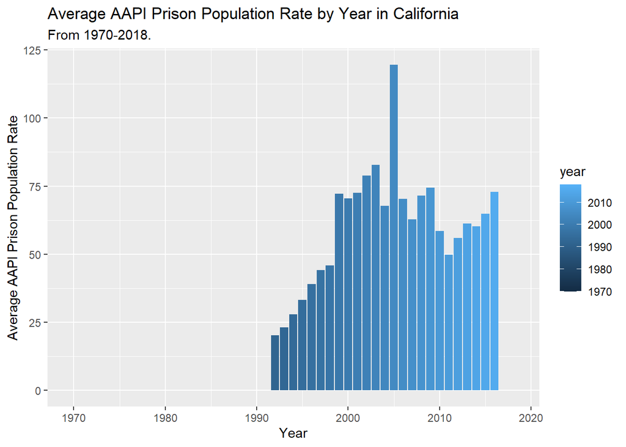

```
From this chart, "Average AAPI Prison Population Rate by Year in California", we see that 2005 has the highest AAPI Prison Population. This might be due to the large amount of AAPI population started to live in California in this year or other possible events related to AAPI population.
```

## Comparison of Total Prison Population between AAPI and White

Below is a *dodge bar chart* I used to show the total prison population between AAPI and White, with gender females and males.

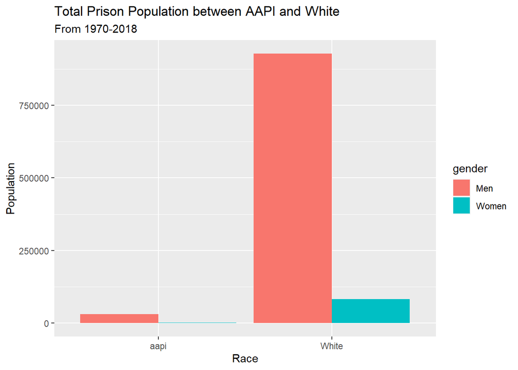

```
From this chart, aapi has relatively lower total prison population comparing to white. The data also shows both aapi and white groups having more male prison population than female prison population.
```

## Map - An Overview on AAPI Total Prison Population among All States

Below is a *map* giving an overview on AAPI total prison population in U.S. from 1970 to 2018.

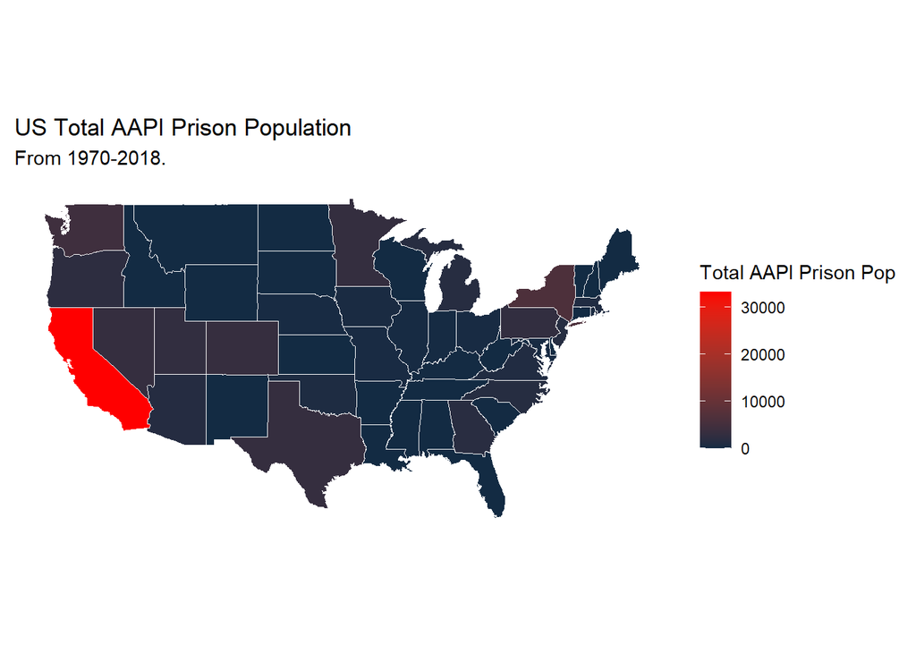

[output not shown]